# Задачи по Эконометрике-2: logit/probit-модель

Н.В. Артамонов (МГИМО МИД России)

# 1 Нормальное и логистическое распределение

Плотность стандартного N(0,1) гауссова распределения $\phi(t)=\frac{1}{\sqrt{2\pi}}\exp(-t^2/2)$ ($t\in\mathbb{R}$). Функция стандартного нормального распределения $\Phi(x)=\int_{-\infty}^x \phi(t)dt$ ($x\in\mathbb{R}$).

Функция логистического распределения $\Lambda(x)=\frac{\exp(x)}{1+\exp(x)}$ ($x\in\mathbb{R}$). Плотность логистического распределения $\lambda(x)=\Lambda'(x)=\frac{\exp(x)}{(1+\exp(x))^2}$

Плотности на одном графике

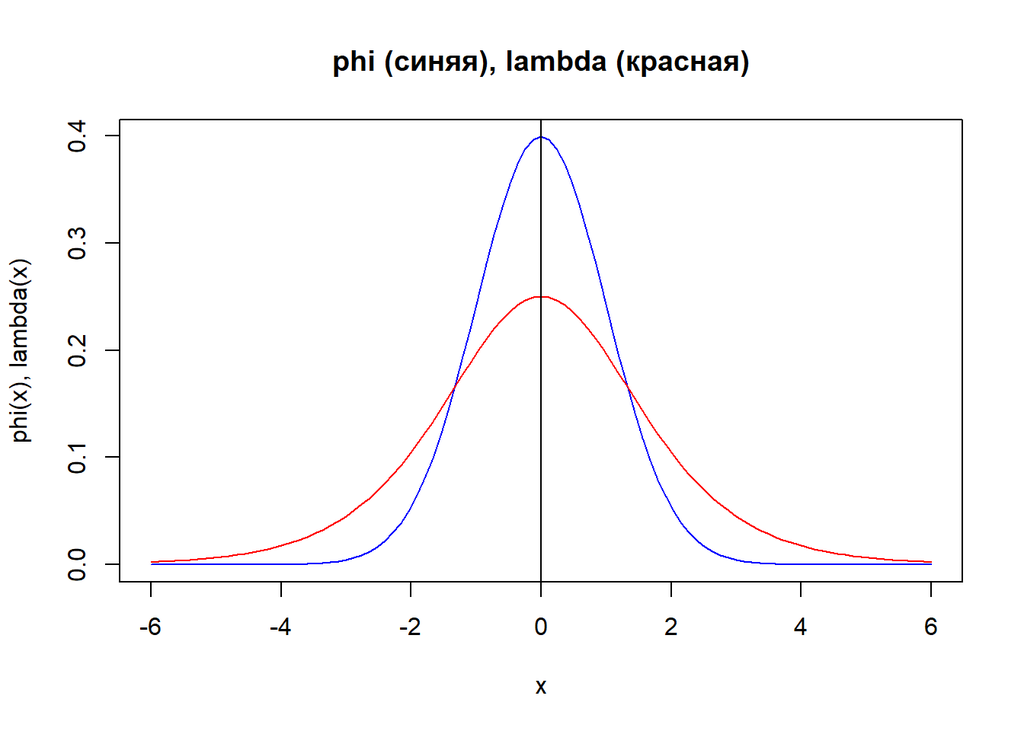

Функции распределения на одном графике

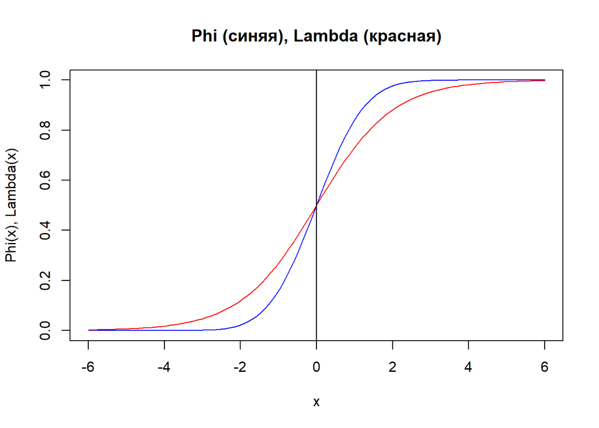

Обратные функции распределение $logit(p)=\Lambda^{-1}(p)=\log\frac{p}{1-p}$ и $probit(p)=\Phi^{-1}(p)$, $0<p<1$

Их графики

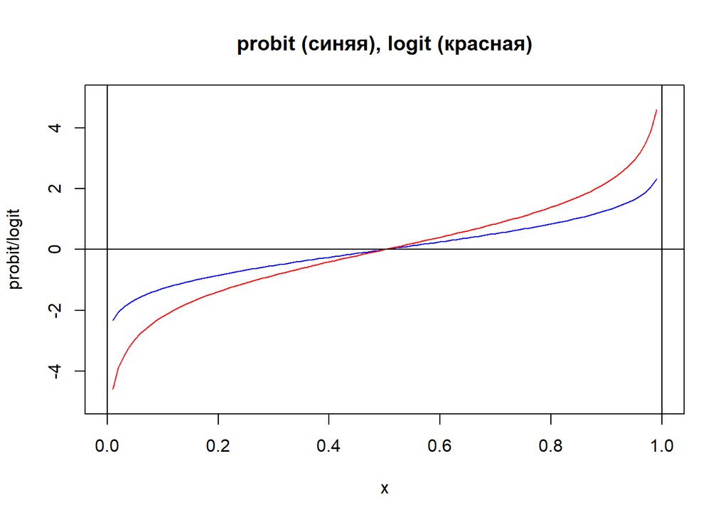

# 2 Оценивание и интерпретация коэффициентов

## 2.1 approve equation #1 (probit)

Для датасета `loanapp` рассморим probit-регрессию **approve на appinc, mortno, unem, dep, male, married, yjob, self**

Спецификация: $P(approve=1)=\Phi(\beta_0+\beta_1appinc+\beta_2mortno+\beta_3unem+\beta_4dep+\beta_5male+\beta_6married+\beta_7yjob+\beta_8self)$

Альтернативная спецификация: $probit(P(approve=1))=\beta_0+\beta_1appinc+\beta_2mortno+\beta_3unem+\beta_4dep+\beta_5male+\beta_6married+\beta_7yjob+\beta_8self$

Оцените модель на данных и укажите коэффициенты подогнанной модели. **Ответ округлите до 3-х десятичных знаков.**

Ответ:

```
(Intercept)      appinc      mortno        unem         dep        male
      1.142      -0.001       0.407      -0.031      -0.083       0.020
    married        yjob        self
      0.221      -0.001      -0.158
```

Дайте интерпретацию коэффициентам модели.

## 2.2 approve equation #2 (logit)

Для датасета `loanapp` рассморим logit-регрессию **approve на appinc, mortno, unem, dep, male, married, yjob, self**

Спецификация: $P(approve=1)=\Lambda(\beta_0+\beta_1appinc+\beta_2mortno+\beta_3unem+\beta_4dep+\beta_5male+\beta_6married+\beta_7yjob+\beta_8self)$

Альтернативная спецификация: $logit(P(approve=1))=\beta_0+\beta_1appinc+\beta_2mortno+\beta_3unem+\beta_4dep+\beta_5male+\beta_6married+\beta_7yjob+\beta_8self$

Здесь $logit(P(approve=1))=\log\frac{P(approve=1)}{1-P(approve=1)}=\log\frac{P(approve=1)}{P(approve=0)}$

Оцените модель на данных и укажите коэффициенты подогнанной модели. **Ответ округлите до 3-х десятичных знаков.**

Ответ:

```
(Intercept)      appinc      mortno        unem         dep        male
      1.931      -0.001       0.787      -0.055      -0.161       0.030
    married        yjob        self
      0.425      -0.006      -0.280
```

Дайте интерпретацию коэффициентам модели.

## 2.3 labour force equation #1 (probit)

Для датасета [mroz_Greene](http://www.stern.nyu.edu/~wgreene/Text/Edition7/TableF5-1.csv) рассморим probit-регрессию **LFP на WA, WA^2, WE, KL6, K618, CIT, UN, log(FAMINC)**

Спецификация: $P(LFP=1)=\Phi(\beta_0+\beta_1WA+\beta_2WA^2+\beta_3WE+\beta_4KL6+\beta_5K618+\beta_5CIT+\beta_7UN+\beta_8\log(FAMINC))$

Альтернативная спецификация: $probit(P(LFP=1))=\beta_0+\beta_1WA+\beta_2WA^2+\beta_3WE+\beta_4KL6+\beta_5K618+\beta_5CIT+\beta_7UN+\beta_8\log(FAMINC)$

Оцените модель на данных и укажите коэффициенты подогнанной модели. **Ответ округлите до 3-х десятичных знаков.**

Ответ:

```
(Intercept)          WA     I(WA^2)          WE         KL6        K618
     -2.005       0.008      -0.001       0.109      -0.851      -0.063
        CIT          UN log(FAMINC)
     -0.128      -0.011       0.200
```

Дайте интерпретацию коэффициентам модели.

## 2.4 labour force equation #2 (logit)

Для датасета [mroz_Greene](http://www.stern.nyu.edu/~wgreene/Text/Edition7/TableF5-1.csv) рассморим logit-регрессию **LFP на WA, WA^2, WE, KL6, K618, CIT, UN, log(FAMINC)**

Спецификация: $P(LFP=1)=\Lambda(\beta_0+\beta_1WA+\beta_2WA^2+\beta_3WE+\beta_4KL6+\beta_5K618+\beta_5CIT+\beta_7UN+\beta_8\log(FAMINC))$

Альтернативная спецификация: $logit(P(LFP=1))=\beta_0+\beta_1WA+\beta_2WA^2+\beta_3WE+\beta_4KL6+\beta_5K618+\beta_5CIT+\beta_7UN+\beta_8\log(FAMINC)$

Здесь $logit(P(LFP=1))=\log\frac{P(LFP=1)}{1-P(LFP=1)}=\log\frac{P(LFP=1)}{P(LFP=0)}$

Оцените модель на данных и укажите коэффициенты подогнанной модели. **Ответ округлите до 3-х десятичных знаков.**

Ответ:

```
(Intercept)          WA     I(WA^2)          WE         KL6        K618
     -3.241       0.007      -0.001       0.180      -1.414      -0.104
        CIT          UN log(FAMINC)
     -0.217      -0.018       0.333
```

Дайте интерпретацию коэффициентам модели.

# 3 z-test

## 3.1 approve equation #1 (probit)

Для датасета `loanapp` рассморим probit-регрессию **approve на appinc, mortno, unem, dep, male, married, yjob, self**

Подгоните модель на данных и приведите результаты z-теста

Ответ:

```
z test of coefficients:

            Estimate Std. Error z value Pr(>|z|)
(Intercept)   1.1418     0.1085 10.5241   <2e-16 ***
appinc       -0.0005     0.0004 -1.3564   0.1750
mortno        0.4071     0.0869  4.6840   <2e-16 ***
unem         -0.0308     0.0162 -1.8961   0.0579 .
dep          -0.0828     0.0352 -2.3558   0.0185 *
male          0.0200     0.0998  0.2002   0.8413
married       0.2208     0.0869  2.5394   0.0111 *
yjob         -0.0007     0.0345 -0.0202   0.9839
self         -0.1583     0.1073 -1.4751   0.1402
---
Signif. codes:  0 '***' 0.001 '**' 0.01 '*' 0.05 '.' 0.1 ' ' 1
```

Модель была подогнана по 1971 наблюдениям. Уровень значимости 10%

Вычислите необходимое критическое значение z-теста. **Ответ округлите до 3-х десятичных знаков.**

```
[1] 1.645
```

Какие коэффициенты значимы? Ответ

```
[1] "(Intercept)" "mortno"      "unem"        "dep"         "married"
```

## 3.2 approve equation #2 (logit)

Для датасета `loanapp` рассморим logit-регрессию **approve на appinc, mortno, unem, dep, male, married, yjob, self**

Подгоните модель на данных и приведите результаты z-теста

Ответ:

```
z test of coefficients:

            Estimate Std. Error z value Pr(>|z|)
(Intercept)   1.9315     0.1993  9.6891   <2e-16 ***
appinc       -0.0010     0.0007 -1.4717   0.1411
mortno        0.7868     0.1721  4.5714   <2e-16 ***
unem         -0.0549     0.0294 -1.8661   0.0620 .
dep          -0.1608     0.0647 -2.4861   0.0129 *
male          0.0300     0.1859  0.1612   0.8719
married       0.4246     0.1624  2.6145   0.0089 **
yjob         -0.0065     0.0651 -0.0993   0.9209
self         -0.2804     0.1967 -1.4257   0.1539
---
Signif. codes:  0 '***' 0.001 '**' 0.01 '*' 0.05 '.' 0.1 ' ' 1
```

Модель была подогнана по 1971 наблюдениям. Уровень значимости 5%

Вычислите необходимое критическое значение z-теста. **Ответ округлите до 3-х десятичных знаков.**

```
[1] 1.96
```

Какие коэффициенты значимы? Ответ

```
[1] "(Intercept)" "mortno"      "dep"         "married"
```

## 3.3 labour force equation #1 (probit)

Для датасета [mroz_Greene](http://www.stern.nyu.edu/~wgreene/Text/Edition7/TableF5-1.csv) рассморим probit-регрессию **LFP на WA, WA^2, WE, KL6, K618, CIT, UN, log(FAMINC)**

Подгоните модель на данных и приведите результаты z-теста

Ответ:

```
z test of coefficients:

            Estimate Std. Error z value Pr(>|z|)
(Intercept)  -2.0046     1.7039 -1.1765   0.2394
WA            0.0076     0.0701  0.1087   0.9135
I(WA^2)      -0.0005     0.0008 -0.6554   0.5122
WE            0.1088     0.0241  4.5144   <2e-16 ***
KL6          -0.8513     0.1154 -7.3778   <2e-16 ***
K618         -0.0632     0.0417 -1.5157   0.1296
CIT          -0.1277     0.1070 -1.1932   0.2328
UN           -0.0106     0.0157 -0.6771   0.4983
log(FAMINC)   0.1996     0.1049  1.9021   0.0572 .
---
Signif. codes:  0 '***' 0.001 '**' 0.01 '*' 0.05 '.' 0.1 ' ' 1
```

Модель была подогнана по 753 наблюдениям. Уровень значимости 10%

Вычислите необходимое критическое значение z-теста. **Ответ округлите до 3-х десятичных знаков.**

```
[1] 1.645
```

Какие коэффициенты значимы? Ответ

```
[1] "WE"          "KL6"         "log(FAMINC)"
```

## 3.4 labour force equation #2 (logit)

Для датасета [mroz_Greene](http://www.stern.nyu.edu/~wgreene/Text/Edition7/TableF5-1.csv) рассморим logit-регрессию **LFP на WA, WA^2, WE, KL6, K618, CIT, UN, log(FAMINC)**

Подгоните модель на данных и приведите результаты z-теста

Ответ:

```
z test of coefficients:

            Estimate Std. Error z value Pr(>|z|)
(Intercept)  -3.2407     2.8337 -1.1436   0.2528
WA            0.0070     0.1159  0.0602   0.9520
I(WA^2)      -0.0008     0.0013 -0.6061   0.5444
WE            0.1800     0.0404  4.4535   <2e-16 ***
KL6          -1.4138     0.1987 -7.1152   <2e-16 ***
K618         -0.1042     0.0687 -1.5166   0.1294
CIT          -0.2165     0.1765 -1.2267   0.2199
UN           -0.0176     0.0258 -0.6812   0.4957
log(FAMINC)   0.3331     0.1729  1.9272   0.0540 .
---
Signif. codes:  0 '***' 0.001 '**' 0.01 '*' 0.05 '.' 0.1 ' ' 1
```

Модель была подогнана по 753 наблюдениям. Уровень значимости 5%

Вычислите необходимое критическое значение z-теста. **Ответ округлите до 3-х десятичных знаков.**

```
[1] 1.96
```

Какие коэффициенты значимы? Ответ

```
[1] "WE"  "KL6"
```

# 4 LR-тест: значимость регресии

## 4.1 approve equation #1 (probit)

Для датасета `loanapp` рассморим probit-регрессию **approve на appinc, unem, male, yjob, self**

Подгоните модель на данных и укажите:

- число наблюдений, на которых была подогнана модель
- логарфим функции правдоподобия для модели $\log L=$-734.0891,
- логарфим функции правдоподобия для регрессии без объясняющих переменных (только на константу)

**Ответ округлите до 3-х десятичных знаков.**

Ответ:

```
[1] "1974 -734.0891 -738.3755"
```

Тестируется значимость регресии, т.е. гипотеза $H_0:\beta_{appinc}=\beta_{unem}=\beta_{male}=\beta_{yjob}=\beta_{self}=0$. Уровень значимости 10%.

Вычислите тестовую статистику. **Ответ округлите до 3-х десятичных знаков.**

Ответ:

```
[1] 8.573
```

Вычислите критическое значение. **Ответ округлите до 3-х десятичных знаков.**

```
[1] 9.236
```

Значима ли регрессия? Ответ

```
[1] "Незначима"
```

Какие коэффициенты значимы?

```
[1] "(Intercept)" "unem"
```

## 4.2 approve equation #2 (logit)

Для датасета `loanapp` рассморим logit-регрессию **approve на appinc, appinc^2, mortno, unem, dep, male, married, yjob, self**

Подгоните модель на данных и укажите:

- число наблюдений, на которых была подогнана модель
- логарфим функции правдоподобия для модели $\log L=$-713.7313,
- логарфим функции правдоподобия для регрессии без объясняющих переменных (только на константу)

**Ответ округлите до 3-х десятичных знаков.**

Ответ:

```
[1] "1971 -713.7313 -737.9793"
```

Вычислите тестовую статистику. **Ответ округлите до 3-х десятичных знаков.**

Ответ:

```
[1] 48.496
```

Вычислите критическое значение. **Ответ округлите до 3-х десятичных знаков.**

```
[1] 16.919
```

Значима ли регрессия? Ответ

```
[1] "Значима"
```

Какие коэффициенты значимы?

```
[1] "(Intercept)" "I(appinc^2)" "mortno"      "dep"         "married"
```

## 4.3 labour force equation #1 (probit)

Для датасета [mroz_Greene](http://www.stern.nyu.edu/~wgreene/Text/Edition7/TableF5-1.csv) рассморим несколько probit-регрессй. Результаты оценивания

```
===========================================================
                            Зависимая переменная
                  -----------------------------------------
                                     LFP
                     (1)        (2)        (3)       (4)
-----------------------------------------------------------
WA                  0.0076    0.1084*   0.1297**
                   (0.0701)   (0.0635)  (0.0630)

I(WA2)             -0.0005    -0.0014*  -0.0016**
                   (0.0008)   (0.0007)  (0.0007)

WE                0.1088***
                   (0.0241)

KL6               -0.8513***
                   (0.1154)

K618               -0.0632
                   (0.0417)

CIT                -0.1277    -0.1026    0.0053    -0.0024
                   (0.1070)   (0.1029)  (0.0983)  (0.0975)

UN                 -0.0106    -0.0101    -0.0102   -0.0115
                   (0.0157)   (0.0152)  (0.0151)  (0.0150)

log(FAMINC)        0.1996*   0.3621***
                   (0.1049)   (0.0957)

Constant           -2.0046   -5.2365***  -2.1745   0.2733*
                   (1.7039)   (1.5600)  (1.3281)  (0.1410)

-----------------------------------------------------------
Observations         753        753        753       753
Log Likelihood    -462.3402  -502.2236  -509.6532 -514.5631
Akaike Inf. Crit.  942.6804  1016.4470  1029.3060 1035.1260
===========================================================
Note:                           *p<0.1; **p<0.05; ***p<0.01
```

Для каждой регресси вычислите LR-статистику для тестирования её значимости. **Ответ округлите до 3-х десятичных знаков.**

Ответ

```
=================
Регрессия LR.stat
-----------------
1         105.066
2         25.299
3         10.440
4          0.620
-----------------
```

Для каждой регрессии вычислите необходимое критическое значение Уровень значимости 10%. **Ответ округлите до 3-х десятичных знаков.**

Ответ

```
=====================
Регрессия Критическое
---------------------
1           13.362
2            9.236
3            7.779
4            4.605
---------------------
```

Какая из регрессий значима?

```
====================
Регрессия Значимость
--------------------
1          Значима
2          Значима
3          Значима
4         Незначима
--------------------
```

## 4.4 labour force equation #2 (logit)

Для датасета [mroz_Greene](http://www.stern.nyu.edu/~wgreene/Text/Edition7/TableF5-1.csv) рассморим несколько logit-регрессй. Результаты оценивания

```
============================================================
                             Зависимая переменная
                  ------------------------------------------
                                     LFP
                     (1)        (2)        (3)        (4)
------------------------------------------------------------
WA                  0.0070
                   (0.1159)

I(WA2)             -0.0008
                   (0.0013)

WE                0.1800***  0.2028***
                   (0.0404)   (0.0396)

KL6               -1.4138*** -1.0154*** -0.8645***
                   (0.1987)   (0.1646)   (0.1585)

K618               -0.1042     0.0509     0.0288    -0.0031
                   (0.0687)   (0.0594)   (0.0581)  (0.0558)

CIT                -0.2165    -0.2753    -0.2200    -0.0043
                   (0.1765)   (0.1726)   (0.1691)  (0.1564)

UN                 -0.0176    -0.0287    -0.0196    -0.0185
                   (0.0258)   (0.0254)   (0.0248)  (0.0240)

log(FAMINC)        0.3331*    0.2808*   0.5829***
                   (0.1729)   (0.1683)   (0.1580)

Constant           -3.2407   -4.3882*** -5.0277***  0.4420*
                   (2.8337)   (1.5718)   (1.5542)  (0.2383)

------------------------------------------------------------
Observations         753        753        753        753
Log Likelihood    -462.2363  -475.6736  -489.7908  -514.5605
Akaike Inf. Crit.  942.4726   965.3473   991.5816  1037.1210
============================================================
Note:                            *p<0.1; **p<0.05; ***p<0.01
```

Для каждой регресси вычислите LR-статистику для тестирования её значимости. **Ответ округлите до 3-х десятичных знаков.**

Ответ

```
=================
Регрессия LR.stat
-----------------
1         105.274
2         78.399
3         50.165
4          0.625
-----------------
```

Для каждой регрессии вычислите необходимое критическое значение Уровень значимости 5%. **Ответ округлите до 3-х десятичных знаков.**

Ответ

```
=====================
Регрессия Критическое
---------------------
1           15.507
2           12.592
3           11.070
4            7.815
---------------------
```

Какая из регрессий значима?

```
====================
Регрессия Значимость
--------------------
1          Значима
2          Значима
3          Значима
4         Незначима
--------------------
```

# 5 LR-тест: совместная значимость

## 5.1 labour force equation #1 (probit)

Для датасета [mroz_Greene](http://www.stern.nyu.edu/~wgreene/Text/Edition7/TableF5-1.csv) рассморим probit-регрессию **LFP на WAб WA^2, WE, KL6, K618, CIT, UN, log(FAMINC)**.

Оцените регрессию на данных и тестируйте следующие гипотезы, используя LR-статистику. Уровень значимости 10%.

### 5.1.1 Гипотеза 1

Тестируется значимость влияния возраста, т.е. гипотеза $H_0:\beta_{WA}=\beta_{WA^2}=0$ по LR-тесту.

Вычислите соотвествующую тестовую статистику. **Ответ округлите до 3-х десятичных знаков.**

```
[1] 26.718
```

Вычислите необходимое кртическое значение. **Ответ округлите до 3-х десятичных знаков.**

```
[1] 4.605
```

Значимо ли влияние возраста? Ответ

```
[1] "Значимо"
```

### 5.1.2 Гипотеза 2

Тестируется совместная значимость влияния **K618, CIT, UN**, т.е. гипотеза $H_0:\beta_{K618}=\beta_{CIT}=\beta_{UN}=0$ по LR-тесту.

Вычислите соотвествующую тестовую статистику. **Ответ округлите до 3-х десятичных знаков.**

```
[1] 4.712
```

Вычислите необходимое кртическое значение. **Ответ округлите до 3-х десятичных знаков.**

```
[1] 6.251
```

Значимо ли влияние переменных? Ответ

```
[1] "Незначимо"
```

### 5.1.3 Гипотеза 3

Тестируется совместная значимость влияния **K618, CIT, UN, FAMINC**, т.е. гипотеза $H_0:\beta_{K618}=\beta_{CIT}=\beta_{UN}=\beta_{\log(FAMINC)}=0$ по LR-тесту.

Вычислите соотвествующую тестовую статистику. **Ответ округлите до 3-х десятичных знаков.**

```
[1] 7.301
```

Вычислите необходимое кртическое значение. **Ответ округлите до 3-х десятичных знаков.**

```
[1] 7.779
```

Значимо ли влияние переменных? Ответ

```
[1] "Незначимо"
```

## 5.2 approve equation #1 (logit)

Оцените регрессию на данных и тестируйте следующие гипотезы, используя LR-статистику. Уровень значимости 1%.

### 5.2.1 Гипотеза 1

Тестируется значимость влияния дохода, т.е. гипотеза $H_0:\beta_{appinc}=\beta_{appinc^2}=0$ по LR-тесту.

Вычислите соотвествующую тестовую статистику. **Ответ округлите до 3-х десятичных знаков.**

```
[1] 7.213
```

Вычислите необходимое кртическое значение. **Ответ округлите до 3-х десятичных знаков.**

```
[1] 9.21
```

```
[1] "Незначимо"
```

### 5.2.2 Гипотеза 2

Тестируется совместная значимость влияния **male, yjob, self**, т.е. гипотеза $H_0:\beta_{male}=\beta_{yjob}=\beta_{self}=0$ по LR-тесту.

Вычислите соотвествующую тестовую статистику. **Ответ округлите до 3-х десятичных знаков.**

```
[1] 3.229
```

Вычислите необходимое кртическое значение. **Ответ округлите до 3-х десятичных знаков.**

```
[1] 11.345
```

Значимо ли влияние переменных? Ответ

```
[1] "Незначимо"
```

### 5.2.3 Гипотеза 3

Тестируется совместная значимость влияния **male, yjob, self, unem, married**, т.е. гипотеза $H_0:\beta_{male}=\beta_{yjob}=\beta_{self}=\beta_{unem}=\beta_{married}=0$ по LR-тесту

Вычислите соотвествующую тестовую статистику. **Ответ округлите до 3-х десятичных знаков.**

```
[1] 13.711
```

Вычислите необходимое кртическое значение. **Ответ округлите до 3-х десятичных знаков.**

```
[1] 15.086
```

Значимо ли влияние переменных? Ответ

```
[1] "Незначимо"
```

# 6 Тест Вальда: совместная значимость

## 6.1 swiss labour force equation #1

Для датасета `SwissLabour` рассморим logit-регрессию **participation на income, income^2, age, age^2, youngkids, oldkids, foreign**

Результаты оценивания

```
MODEL INFO:
Observations: 872
Dependent Variable: as.numeric(participation) - 1
Type: Generalized linear model
  Family: binomial
  Link function: logit

MODEL FIT:
χ²(7) = 185.1659, p = 0.0000
Pseudo-R² (Cragg-Uhler) = 0.2556
Pseudo-R² (McFadden) = 0.1539
AIC = 1034.0575, BIC = 1072.2238

Standard errors: MLE
-------------------------------------------------------------------
                       Est.      S.E.    z val.        p        VIF
----------------- --------- --------- --------- -------- ----------
(Intercept)         -9.4763   17.2451   -0.5495   0.5827
income               1.8753    3.2660    0.5742   0.5658   276.5677
I(income^2)         -0.1377    0.1552   -0.8875   0.3748   276.4963
age                  3.4025    0.6866    4.9553   0.0000    83.0214
I(age^2)            -0.4846    0.0851   -5.6916   0.0000    83.3744
youngkids           -1.1813    0.1723   -6.8578   0.0000     1.5869
oldkids             -0.2471    0.0843   -2.9321   0.0034     1.4726
foreignyes           1.0728    0.1870    5.7371   0.0000     1.0847
-------------------------------------------------------------------
```

Оцените регрессию на данных и тестируйте следующие гипотезы, используя $\chi^2$-статистику Вальда. Уровень значимости 5%.

### 6.1.1 Гипотеза 1

Тестируется значимость влияния дохода, т.е. гипотеза $H_0:\beta_{income}=\beta_{income^2}=0$.

Вычислите статику теста Вальда и P-значение.

```
==================
Chisq  Pr(> Chisq)
------------------
24.441   0.00000
------------------
```

Вычислите критическое значение. **Ответ округлите до 3-х десятичных знаков.**

```
[1] 5.991
```

Значимо ли влияние дохода? Ответ

```
[1] "Значимо"
```

### 6.1.2 Гипотеза 2

Тестируется значимость влияния числа детей, т.е. гипотеза $H_0:\beta_{youngkids}=\beta_{oldkids}=0$. Вычислите статику теста Вальда и P-значение.

```
==================
Chisq  Pr(> Chisq)
------------------
48.420      0
------------------
```

Вычислите критическое значение. **Ответ округлите до 3-х десятичных знаков.**

```
[1] 5.991
```

Значимо ли влияние числе детей? Ответ

```
[1] "Значимо"
```

### 6.1.3 Гипотеза 3

Тестируется значимость влияния возраста, т.е. гипотеза $H_0:\beta_{age}=\beta_{age^2}=0$. Вычислите статику теста Вальда и P-значение.

```
==================
Chisq  Pr(> Chisq)
------------------
58.911      0
------------------
```

Вычислите критическое значение. **Ответ округлите до 3-х десятичных знаков.**

```
[1] 5.991
```

Значимо ли влияние возраста? Ответ

```
[1] "Значимо"
```